# Lab-9 Template

Answer questions in the designated cells.

Rename notebook to include your name and NET-ID in the file name. Submit two versions of your notebook:

- Original notebook
- HTML version. Make sure to produce Shapley plots using `matplotlib=True` option so that your plots are displayed in the HTML version
- Validate that all plots are displayed in the HTML version
- You can use `matplotlib=False` in the original version to get nicer plots

No need to encode missing values or categorical variables, other than make sure H2O recognizes them properly. Use `asfactor` if need to correct encoding.

Use H2O to train models.

Resources:

- https://github.com/slundberg/shap
- H2O Explainability best practices: https://github.com/h2oai/h2o-tutorials/blob/master/best-practices/model-interpretability/interpreting_models.ipynb

Materials by Patrick Hall: https://github.com/jphall663/interpretable_machine_learning_with_python https://github.com/jphall663/interpretable_machine_learning_with_python/blob/master/debugging_resid_analysis_redux.ipynb  
Decision tree plotting: https://github.com/h2oai/h2o-tutorials/blob/master/best-practices/model-interpretability/interpreting_models.ipynb

## Preparation

Use dataset provided in the eLearning

```python
#Extend cell width
from IPython.core.display import display, HTML
display(HTML("<style>.container { width:80% !important; }</style>"))

import warnings
warnings.filterwarnings('ignore')

import pandas as pd

#Install shap package as needed:
#!pip uninstall numpy
#!pip uninstall numba
#!pip install shap==0.40.0

import shap

import h2o
from h2o.estimators import H2OTargetEncoderEstimator

try:
    h2o.cluster().shutdown()
except:
    pass
```

```python
#Limit to 3 threads and 8GB memory
h2o.init(nthreads=3, max_mem_size=8)
```

```
Checking whether there is an H2O instance running at http://localhost:54321 . connected.
```

| H2O_cluster_uptime: | 7 days 0 hours 49 mins |
| --- | --- |
| H2O_cluster_timezone: | America/Chicago |
| H2O_data_parsing_timezone: | UTC |
| H2O_cluster_version: | 3.36.0.3 |
| H2O_cluster_version_age: | 2 months and 16 days |
| H2O_cluster_name: | H2O_from_python_dasariramesh_4r6k4k |
| H2O_cluster_total_nodes: | 1 |
| H2O_cluster_free_memory: | 6.935 Gb |
| H2O_cluster_total_cores: | 8 |
| H2O_cluster_allowed_cores: | 3 |
| H2O_cluster_status: | locked, healthy |
| H2O_connection_url: | http://localhost:54321 |
| H2O_connection_proxy: | {"http": null, "https": null} |
| H2O_internal_security: | False |
| Python_version: | 3.9.7 final |

### Load data

```python
train = h2o.import_file('Car_Prices_Poland_train.csv')
test = h2o.import_file('Car_Prices_Poland_test.csv')
```

```
Parse progress: |████████████████████████████████████████████████████████████████| (done) 100%
Parse progress: |████████████████████████████████████████████████████████████████| (done) 100%
```

```python
train.head(5)
```

| mark | model | generation_name | year | mileage | vol_engine | fuel | city | province | price |
| --- | --- | --- | --- | --- | --- | --- | --- | --- | --- |
| opel | insignia | gen-a-2008-2017 | 2009 | 106125 | 1796 | Gasoline | Częstochowa | Śląskie | 25000 |
| skoda | fabia | gen-ii-2007 | 2010 | 207000 | 1200 | Gasoline | Bydgoszcz | Kujawsko-pomorskie | 11900 |
| opel | insignia | gen-a-2008-2017 | 2013 | 195000 | 1956 | Diesel | Ruda Śląska | Śląskie | 24598 |
| audi | a4 | gen-b8-2007-2015 | 2012 | 280000 | 1968 | Diesel | Białystok | Podlaskie | 41900 |
| citroen | c4-picasso | gen-ii-2013-c4-picasso | 2014 | 122200 | 1560 | Diesel | Dziemionna | Kujawsko-pomorskie | 39500 |

```python
print("Train shape:", train.shape)
print("Test shape:", test.shape)
```

```
Train shape: (88445, 10)
Test shape: (29482, 10)
```

```python
train.describe()
```

```
Rows:88445
Cols:10
```

|  | mark | model | generation_name | year | mileage | vol_engine | fuel | city | province | price |
| --- | --- | --- | --- | --- | --- | --- | --- | --- | --- | --- |
| type | enum | enum | enum | int | int | int | enum | enum | enum | int |
| mins |  |  |  | 1964.0 | 0.0 | 0.0 |  |  |  | 500.0 |
| mean |  |  |  | 2012.933427553847 | 140832.01954887222 | 1812.3419074000792 |  |  |  | 70347.49990389505 |
| maxs |  |  |  | 2022.0 | 2800000.0 | 7600.0 |  |  |  | 2399900.0 |
| sigma |  |  |  | 5.684015918888915 | 92510.79953360025 | 646.7315007474649 |  |  |  | 85275.90175596683 |
| zeros |  |  |  | 0 | 283 | 936 |  |  |  | 0 |
| missing | 0 | 0 | 22551 | 0 | 0 | 0 | 0 | 0 | 0 | 0 |
| 0 | opel | insignia | gen-a-2008-2017 | 2009.0 | 106125.0 | 1796.0 | Gasoline | Częstochowa | Śląskie | 25000.0 |
| 1 | skoda | fabia | gen-ii-2007 | 2010.0 | 207000.0 | 1200.0 | Gasoline | Bydgoszcz | Kujawsko-pomorskie | 11900.0 |
| 2 | opel | insignia | gen-a-2008-2017 | 2013.0 | 195000.0 | 1956.0 | Diesel | Ruda Śląska | Śląskie | 24598.0 |
| 3 | audi | a4 | gen-b8-2007-2015 | 2012.0 | 280000.0 | 1968.0 | Diesel | Białystok | Podlaskie | 41900.0 |
| 4 | citroen | c4-picasso | gen-ii-2013-c4-picasso | 2014.0 | 122200.0 | 1560.0 | Diesel | Dziemionna | Kujawsko-pomorskie | 39500.0 |
| 5 | bmw | m3 |  | 2018.0 | 44000.0 | 2979.0 | Gasoline | Kraków | Małopolskie | 299900.0 |
| 6 | skoda | superb | gen-iii-2015 | 2016.0 | 115456.0 | 1968.0 | Diesel | Chorzów | Śląskie | 75900.0 |
| 7 | audi | a4 | gen-b9-2015 | 2017.0 | 84000.0 | 1968.0 | Diesel | Tarczyn | Mazowieckie | 112500.0 |
| 8 | opel | astra | gen-j-2009-2015 | 2010.0 | 75000.0 | 1598.0 | Gasoline | Truskolasy | Śląskie | 33333.0 |
| 9 | ford | focus | gen-mk3-2010 | 2013.0 | 199997.0 | 1560.0 | Diesel | Gdynia | Pomorskie | 29900.0 |

## Question 1

Train H2O `H2OGradientBoostingEstimator` with parameters:

```
nfolds=5,
ntrees=500,
stopping_rounds=5,
stopping_metric='MAE',
seed=1234,
keep_cross_validation_predictions = False
```

Display model performance on `test` dataset using `model_performance` function.

```python
from h2o.estimators.gbm import H2OGradientBoostingEstimator
```

```python
response = "price"
predictors = train.columns
```

```python
train.head(2)
```

| mark | model | generation_name | year | mileage | vol_engine | fuel | city | province | price |
| --- | --- | --- | --- | --- | --- | --- | --- | --- | --- |
| opel | insignia | gen-a-2008-2017 | 2009 | 106125 | 1796 | Gasoline | Częstochowa | Śląskie | 25000 |
| skoda | fabia | gen-ii-2007 | 2010 | 207000 | 1200 | Gasoline | Bydgoszcz | Kujawsko-pomorskie | 11900 |

```python
gbm = H2OGradientBoostingEstimator(nfolds=5,
                                   ntrees=500,
                                   stopping_rounds=5,
                                   stopping_metric='MAE',
                                   seed=1234,
                                   keep_cross_validation_predictions = False)
gbm.train(x=predictors, y=response, training_frame=train)
```

```
gbm Model Build progress: |██████████████████████████████████████████████████████| (done) 100%
Model Details
=============
H2OGradientBoostingEstimator :  Gradient Boosting Machine
Model Key:  GBM_model_python_1650981926751_128


Model Summary:
```

|  |  | number_of_trees | number_of_internal_trees | model_size_in_bytes | min_depth | max_depth | mean_depth | min_leaves | max_leaves | mean_leaves |
| --- | --- | --- | --- | --- | --- | --- | --- | --- | --- | --- |
| 0 |  | 414.0 | 414.0 | 321254.0 | 0.0 | 5.0 | 4.987923 | 1.0 | 32.0 | 21.5314 |

```
ModelMetricsRegression: gbm
** Reported on train data. **

MSE: 214553675.7732535
RMSE: 14647.650861938699
MAE: 7043.073439586147
RMSLE: NaN
Mean Residual Deviance: 214553675.7732535

ModelMetricsRegression: gbm
** Reported on cross-validation data. **

MSE: 416537270.66263515
RMSE: 20409.24473523298
MAE: 8449.21340273332
RMSLE: NaN
Mean Residual Deviance: 416537270.66263515

Cross-Validation Metrics Summary:
```

|  |  | mean | sd | cv_1_valid | cv_2_valid | cv_3_valid | cv_4_valid | cv_5_valid |
| --- | --- | --- | --- | --- | --- | --- | --- | --- |
| 0 | mae | 8.449479e+03 | 8.981095e+01 | 8.427125e+03 | 8.390564e+03 | 8.469036e+03 | 8.594365e+03 | 8.366300e+03 |
| 1 | mean_residual_deviance | 4.166815e+08 | 5.317502e+07 | 4.816688e+08 | 3.864561e+08 | 3.447609e+08 | 4.228021e+08 | 4.477197e+08 |
| 2 | mse | 4.166815e+08 | 5.317502e+07 | 4.816688e+08 | 3.864561e+08 | 3.447609e+08 | 4.228021e+08 | 4.477197e+08 |
| 3 | r2 | 9.427723e-01 | 6.514796e-03 | 9.342327e-01 | 9.470950e-01 | 9.510755e-01 | 9.413870e-01 | 9.400709e-01 |
| 4 | residual_deviance | 4.166815e+08 | 5.317502e+07 | 4.816688e+08 | 3.864561e+08 | 3.447609e+08 | 4.228021e+08 | 4.477197e+08 |
| 5 | rmse | 2.037894e+04 | 1.313472e+03 | 2.194696e+04 | 1.965849e+04 | 1.856774e+04 | 2.056215e+04 | 2.115939e+04 |
| 6 | rmsle | 2.046725e-01 | 4.942679e-04 | NaN | NaN | 2.043230e-01 | 2.050220e-01 | NaN |

```
Scoring History:
```

|  |  | timestamp | duration | number_of_trees | training_rmse | training_mae | training_deviance |
| --- | --- | --- | --- | --- | --- | --- | --- |
| 0 |  | 2022-05-03 09:55:58 | 55.614 sec | 0.0 | 85275.419670 | 54099.707244 | 7.271897e+09 |
| 1 |  | 2022-05-03 09:55:58 | 55.672 sec | 1.0 | 77852.963657 | 49180.899350 | 6.061084e+09 |
| 2 |  | 2022-05-03 09:55:58 | 55.704 sec | 2.0 | 71173.119710 | 44686.065949 | 5.065613e+09 |
| 3 |  | 2022-05-03 09:55:58 | 55.737 sec | 3.0 | 65253.695788 | 40686.696648 | 4.258045e+09 |
| 4 |  | 2022-05-03 09:55:58 | 55.764 sec | 4.0 | 59960.004538 | 37133.135870 | 3.595202e+09 |
| 5 |  | 2022-05-03 09:55:58 | 55.796 sec | 5.0 | 55219.860556 | 33875.590724 | 3.049233e+09 |
| 6 |  | 2022-05-03 09:55:58 | 55.835 sec | 6.0 | 51001.242887 | 30953.804177 | 2.601127e+09 |
| 7 |  | 2022-05-03 09:55:58 | 55.871 sec | 7.0 | 47269.462075 | 28364.818221 | 2.234402e+09 |
| 8 |  | 2022-05-03 09:55:58 | 55.905 sec | 8.0 | 43973.922545 | 26078.804954 | 1.933706e+09 |
| 9 |  | 2022-05-03 09:55:58 | 55.938 sec | 9.0 | 40966.177335 | 24047.767213 | 1.678228e+09 |
| 10 |  | 2022-05-03 09:55:58 | 55.973 sec | 10.0 | 38334.979301 | 22260.603147 | 1.469571e+09 |
| 11 |  | 2022-05-03 09:55:58 | 56.006 sec | 11.0 | 36015.009491 | 20668.973001 | 1.297081e+09 |
| 12 |  | 2022-05-03 09:55:58 | 56.038 sec | 12.0 | 33935.255171 | 19216.620272 | 1.151602e+09 |
| 13 |  | 2022-05-03 09:55:58 | 56.071 sec | 13.0 | 32209.915099 | 18001.766670 | 1.037479e+09 |
| 14 |  | 2022-05-03 09:55:58 | 56.106 sec | 14.0 | 30625.686837 | 16889.581237 | 9.379327e+08 |
| 15 |  | 2022-05-03 09:55:59 | 56.139 sec | 15.0 | 29244.315591 | 15944.063559 | 8.552300e+08 |
| 16 |  | 2022-05-03 09:55:59 | 56.180 sec | 16.0 | 28044.285302 | 15089.342743 | 7.864819e+08 |
| 17 |  | 2022-05-03 09:55:59 | 56.229 sec | 17.0 | 26999.506076 | 14310.467925 | 7.289733e+08 |
| 18 |  | 2022-05-03 09:55:59 | 56.260 sec | 18.0 | 26051.081662 | 13642.818931 | 6.786589e+08 |
| 19 |  | 2022-05-03 09:55:59 | 56.291 sec | 19.0 | 25288.656267 | 13061.447081 | 6.395161e+08 |

```
See the whole table with table.as_data_frame()

Variable Importances:
```

|  | variable | relative_importance | scaled_importance | percentage |
| --- | --- | --- | --- | --- |
| 0 | model | 1.374078e+15 | 1.000000 | 0.418268 |
| 1 | year | 1.353937e+15 | 0.985342 | 0.412137 |
| 2 | generation_name | 2.344093e+14 | 0.170594 | 0.071354 |
| 3 | vol_engine | 1.675911e+14 | 0.121966 | 0.051015 |
| 4 | mileage | 1.176537e+14 | 0.085624 | 0.035814 |
| 5 | province | 2.178399e+13 | 0.015854 | 0.006631 |
| 6 | fuel | 8.251588e+12 | 0.006005 | 0.002512 |
| 7 | city | 7.255359e+12 | 0.005280 | 0.002209 |
| 8 | mark | 2.038045e+11 | 0.000148 | 0.000062 |

```python
perf = gbm.model_performance(test)
```

```python
print(perf)
```

```
ModelMetricsRegression: gbm
** Reported on test data. **

MSE: 340260887.24929273
RMSE: 18446.16185685501
MAE: 8205.120294637314
RMSLE: NaN
Mean Residual Deviance: 340260887.24929273
```

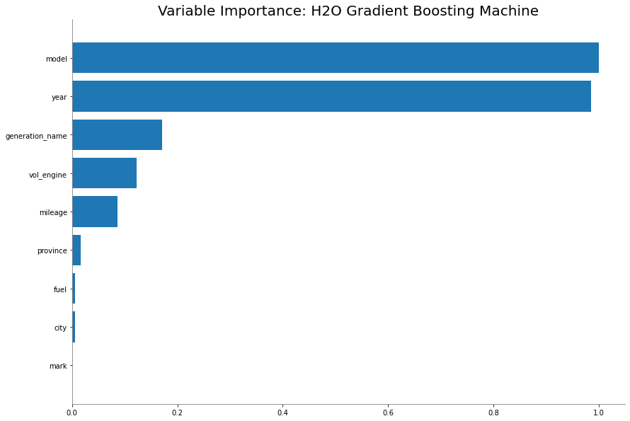

```
<h2o.plot._plot_result._MObject at 0x7fe7903d2ca0>
```

```python
gbm.varimp_plot()
```

## Question 2

Use model from Question 1 to answer Q#2.

- Calculate and display permutation feature importance for the model using **test** dataset
- What is most important feature?
- Can you tell how feature is impacting (direction) probability?

```python
permutation_varimp = gbm.permutation_importance(test, use_pandas=True)
```

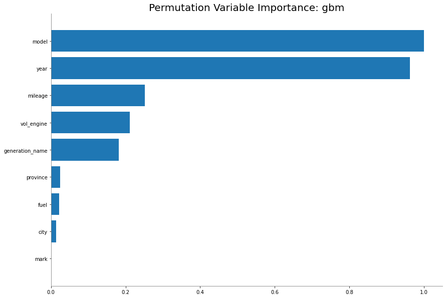

```
Variable Importances:
```

|  | Variable | Relative Importance | Scaled Importance | Percentage |
| --- | --- | --- | --- | --- |
| 0 | model | 46087.822252 | 1.000000 | 0.374950 |
| 1 | year | 44343.782201 | 0.962158 | 0.360761 |
| 2 | mileage | 11593.157690 | 0.251545 | 0.094317 |
| 3 | vol_engine | 9722.643372 | 0.210959 | 0.079099 |
| 4 | generation_name | 8400.056512 | 0.182262 | 0.068339 |
| 5 | province | 1150.112575 | 0.024955 | 0.009357 |
| 6 | fuel | 979.128844 | 0.021245 | 0.007966 |
| 7 | city | 631.181840 | 0.013695 | 0.005135 |
| 8 | mark | 9.480917 | 0.000206 | 0.000077 |

```python
gbm.permutation_importance_plot(test)
```

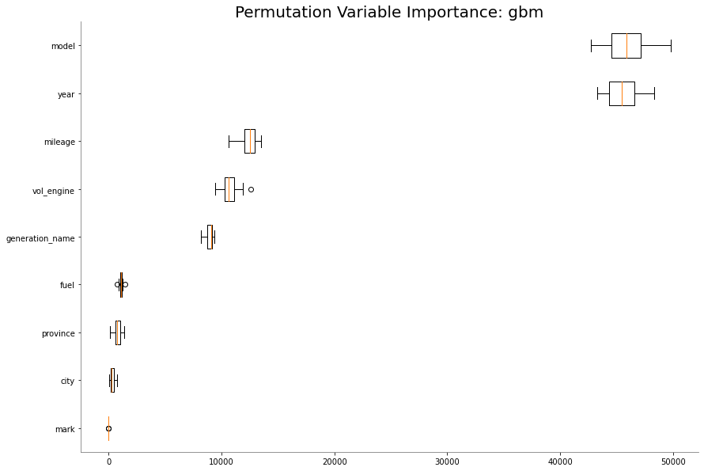

```
Variable Importances:
```

|  | Variable | Run 1 | Run 2 | Run 3 | Run 4 | Run 5 | Run 6 | Run 7 | Run 8 | Run 9 | Run 10 | Run 11 | Run 12 | Run 13 | Run 14 | Run 15 |
| --- | --- | --- | --- | --- | --- | --- | --- | --- | --- | --- | --- | --- | --- | --- | --- | --- |
| 0 | model | 45864.040528 | 47172.259368 | 42755.831725 | 46638.524172 | 43362.700997 | 43091.040346 | 45095.952296 | 46774.832097 | 47150.595764 | 49774.607149 | 44331.906047 | 45625.694572 | 47659.488016 | 44751.596044 | 48607.903765 |
| 1 | year | 45603.426055 | 44970.719385 | 43288.405264 | 45465.831656 | 43978.458261 | 43922.358683 | 46851.345830 | 45249.799333 | 47391.384321 | 48352.886557 | 46004.838425 | 44440.804175 | 48063.223752 | 44304.591809 | 46253.957641 |
| 2 | mileage | 11727.480843 | 13518.059505 | 10642.282160 | 12321.549245 | 11564.536900 | 11409.506274 | 12707.963020 | 12667.333892 | 13412.716587 | 13454.122343 | 12501.389582 | 12274.041189 | 13018.471443 | 12328.272424 | 12809.898633 |
| 3 | vol_engine | 10174.931840 | 12589.828673 | 10705.146424 | 10630.078311 | 9441.775954 | 10976.293705 | 10580.987891 | 11043.733301 | 10478.547868 | 11626.964343 | 10345.815044 | 9727.055023 | 11921.365205 | 9932.829576 | 11240.157623 |
| 4 | generation_name | 8380.937479 | 9105.502230 | 9065.543271 | 8208.104888 | 9364.423815 | 9116.873232 | 8257.692698 | 8959.983497 | 8628.408118 | 9192.045769 | 9150.676623 | 8819.048389 | 9354.926392 | 8977.361371 | 9279.059804 |
| 5 | fuel | 1003.851723 | 1136.643524 | 777.279794 | 1264.273322 | 1139.452194 | 1208.835029 | 972.166960 | 1099.429416 | 1418.656618 | 1097.812052 | 1182.363209 | 1041.341449 | 867.201855 | 1099.861626 | 1163.857877 |
| 6 | province | 659.973562 | 1344.227441 | 279.531568 | 749.206671 | 680.103504 | 1396.532243 | 121.743838 | 917.470269 | 554.553254 | 1275.095820 | 559.420408 | 732.180005 | 970.879107 | 1091.579949 | 959.025039 |
| 7 | city | 23.768917 | 285.698157 | 290.220886 | 495.600760 | 220.632256 | 85.040661 | 624.862333 | 671.364670 | 178.308988 | 275.411819 | 770.218594 | 146.371152 | 318.900392 | 249.737418 | 428.864248 |
| 8 | mark | 1.261007 | 0.208848 | 2.604178 | 10.523896 | 0.432838 | 1.895487 | 10.981931 | 4.754882 | 2.865139 | 1.845514 | 0.578770 | 0.207957 | 0.758921 | 5.769599 | 0.105833 |

```python
gbm.permutation_importance_plot(test, n_repeats=15)
```

## Question 3

Calculate absolute error percentage of the price on test dataset. Add absolute error column to the dataset and call it `abs_error`.

Formula: `abs(price-predict_price)`

```python
pred = gbm.predict(test)
```

```
gbm prediction progress: |███████████████████████████████████████████████████████| (done) 100%
```

```python
test.head(2)
```

| mark | model | generation_name | year | mileage | vol_engine | fuel | city | province | price |
| --- | --- | --- | --- | --- | --- | --- | --- | --- | --- |
| skoda | octavia | gen-iii-2013 | 2016 | 63000 | 1598 | Diesel | Szamotuły | Wielkopolskie | 49500 |
| ford | mustang |  | 1967 | 1 | 6384 | Gasoline | Łódź | Łódzkie | 379900 |

```python
test['abs_error'] = abs((test['price'] - pred['predict']) / test['price'])
```

```python
test.head(2)
```

| mark | model | generation_name | year | mileage | vol_engine | fuel | city | province | price | abs_error |
| --- | --- | --- | --- | --- | --- | --- | --- | --- | --- | --- |
| skoda | octavia | gen-iii-2013 | 2016 | 63000 | 1598 | Diesel | Szamotuły | Wielkopolskie | 49500 | 0.144538 |
| ford | mustang |  | 1967 | 1 | 6384 | Gasoline | Łódź | Łódzkie | 379900 | 0.141742 |

## Question 4

Calculate and display summary plot of Shapley values. Use `test` dataset to calculate Shapley values.

- What is the most important feature based on Shapley values?
- Based on the Summary plot, how features `year` and `mileage` affect model precition of the car price?

```python
test.shape
```

```
(29482, 11)
```

```python
# calculate SHAP values using function predict_contributions
contributions = gbm.predict_contributions(test)
```

```
contributions progress: |████████████████████████████████████████████████████████| (done) 100%
```

```python
# convert the H2O Frame to use with shap's visualization functions
contributions_matrix = contributions.as_data_frame().to_numpy()
```

```python
len(contributions_matrix)
```

```
29482
```

```python
# shap values are calculated for all features
shap_values = contributions_matrix[:,0:11]
```

```python
# expected values is the last returned column
expected_value = contributions_matrix[:,9].min()
```

```python
test.head(2)
```

| mark | model | generation_name | year | mileage | vol_engine | fuel | city | province | price | abs_error |
| --- | --- | --- | --- | --- | --- | --- | --- | --- | --- | --- |
| skoda | octavia | gen-iii-2013 | 2016 | 63000 | 1598 | Diesel | Szamotuły | Wielkopolskie | 49500 | 0.144538 |
| ford | mustang |  | 1967 | 1 | 6384 | Gasoline | Łódź | Łódzkie | 379900 | 0.141742 |

```python
X = ['mark','model','generation_name','year','mileage','vol_engine','fuel','city','province','abs_error']
```

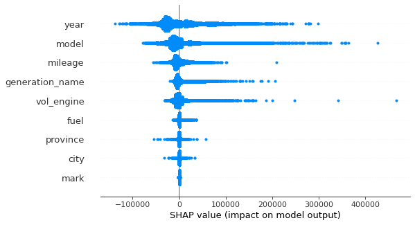

```python
shap.summary_plot(shap_values[:,0:9], X)
```

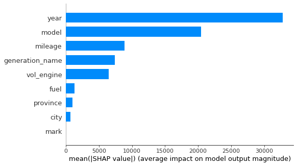

```python
shap.summary_plot(shap_values[:,0:9], X, plot_type="bar")
```

## Question 5

Plot individual Shapley values plots for records top 3 and bottom 3 records based on the residuals, for the total of 6 plots.

Explain each plot in terms of what are most influential features and how they impact model prediction, and why you think model was correct for the top 3 records (smallest residuals) and significantly incorrect for the bottom 3 records (largest residuals).

```python
shap_val = pd.DataFrame(shap_values,columns = X)
```

```python
shap_val = shap_val.sort_values(by = ['abs_error'],ascending=False)
```

```python
shap_val['index1'] = shap_val.index
```

```python
shap_val.head(2)
```

|  | mark | model | generation_name | year | mileage | vol_engine | fuel | city | province | abs_error | index1 |
| --- | --- | --- | --- | --- | --- | --- | --- | --- | --- | --- | --- |
| 0 | -3.333934 | -9486.784180 | 1131.937622 | 2129.437988 | 4052.364502 | -7179.884277 | -2523.972168 | 345.628693 | -2158.240967 | 70347.5 | 0 |
| 19663 | -2.870458 | -12184.787109 | -5223.185547 | -28457.732422 | -7756.956055 | -3414.360352 | 294.713287 | -360.534851 | 592.494873 | 70347.5 | 19663 |

```python
top_3 = shap_val.iloc[0:3,:]
```

```python
bottom_3 = shap_val.iloc[-3:,:]
```

[output not shown]

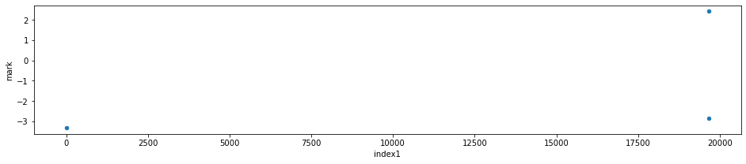

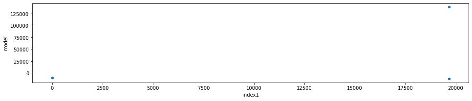

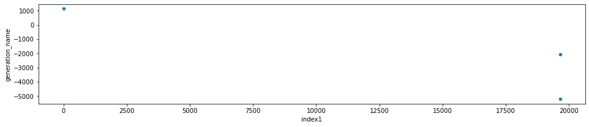

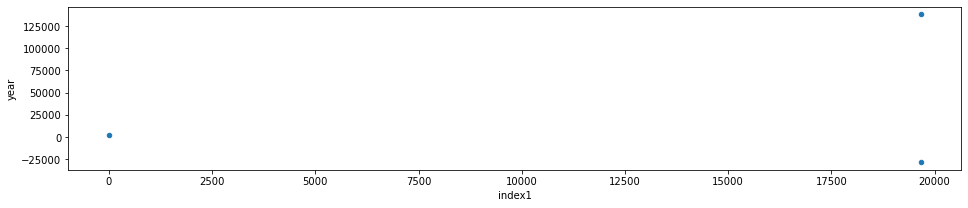

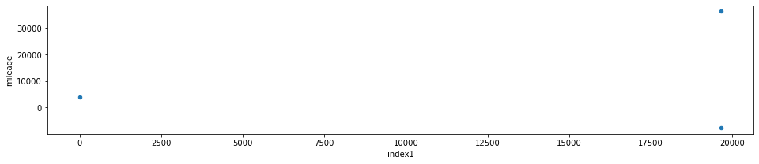

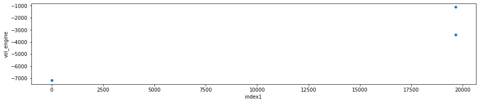

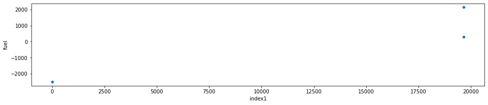

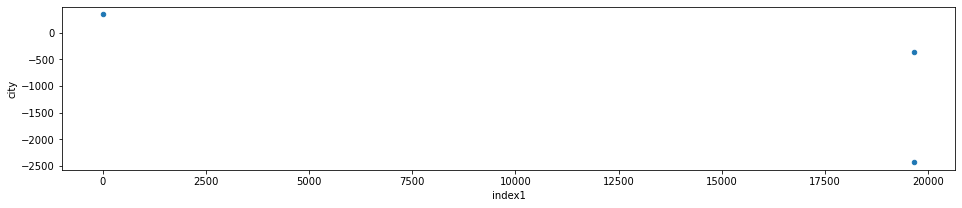

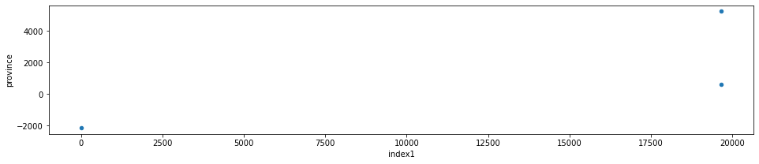

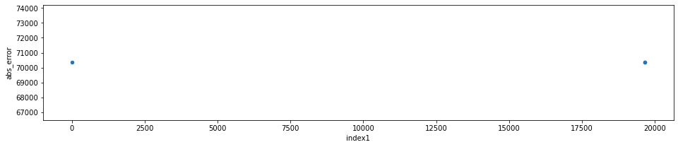

```python
cols = [x for x in shap_val.columns if x not in ['index1']]
for i in cols:
    print(top_3.plot.scatter(x = 'index1',y=i,figsize=(16,3)));
```

[output not shown]

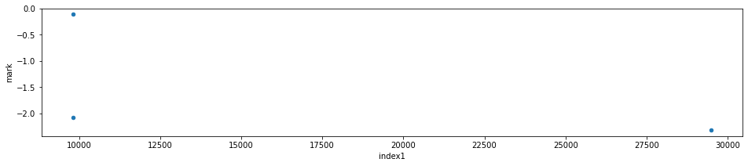

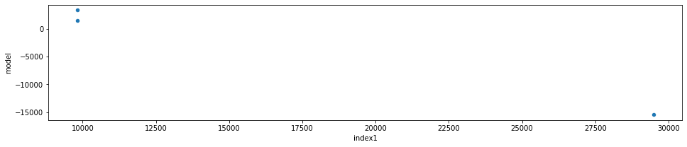

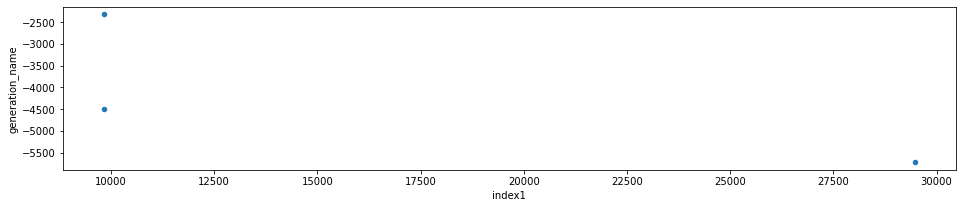

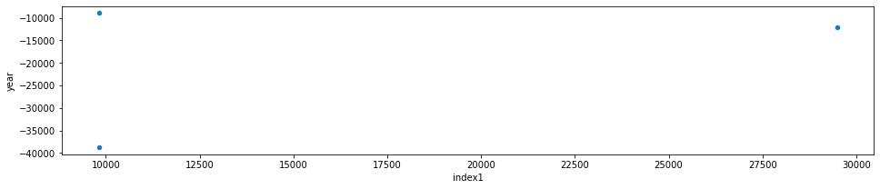

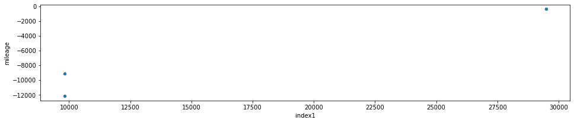

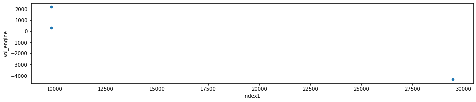

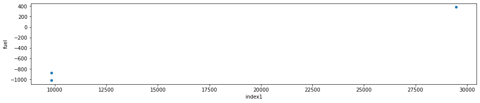

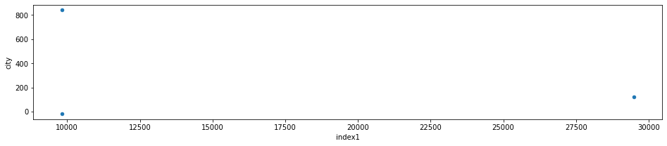

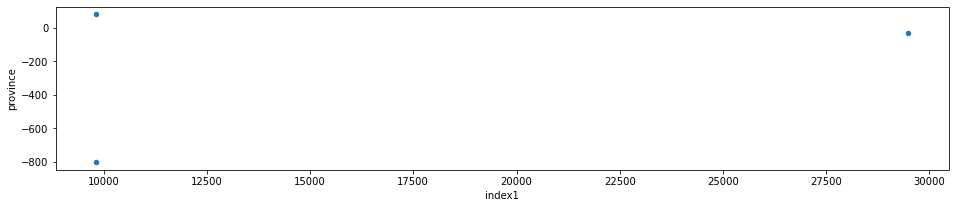

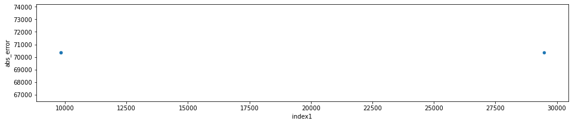

```python
cols = [x for x in shap_val.columns if x not in ['index1']]
for i in cols:
    print(bottom_3.plot.scatter(x = 'index1',y=i,figsize=(16,3)));
```

## Question 6

Train new H2O GBM model on the test dataset trying to predict residuals. This is your surrogate modedel that you will use to understand what features are driving high residuals.

Use same parameters as in question #1, except:

- predictor is now "abs_error"
- dataset now is "test" dataset
- make sure not to include original "price" column in the model

Plot Shapley summary plot for the top 100 records with highest residuals. Answer following question:

- What is the most important feature of the surrogate model that impacts high residuals?

```python
test_new = test.drop(['price'])
```

```python
response = "abs_error"
predictors = test_new.columns
```

```python
gbm_test = H2OGradientBoostingEstimator(nfolds=5,
                                   ntrees=500,
                                   stopping_rounds=5,
                                   stopping_metric='MAE',
                                   seed=1234,
                                   keep_cross_validation_predictions = False)
gbm_test.train(x=predictors, y=response, training_frame=test_new)
```

```
gbm Model Build progress: |██████████████████████████████████████████████████████| (done) 100%
Model Details
=============
H2OGradientBoostingEstimator :  Gradient Boosting Machine
Model Key:  GBM_model_python_1650981926751_129


Model Summary:
```

|  |  | number_of_trees | number_of_internal_trees | model_size_in_bytes | min_depth | max_depth | mean_depth | min_leaves | max_leaves | mean_leaves |
| --- | --- | --- | --- | --- | --- | --- | --- | --- | --- | --- |
| 0 |  | 17.0 | 17.0 | 17061.0 | 5.0 | 5.0 | 5.0 | 21.0 | 31.0 | 26.0 |

```
ModelMetricsRegression: gbm
** Reported on train data. **

MSE: 0.036419351841242835
RMSE: 0.19083854914886256
MAE: 0.09467894021069086
RMSLE: 0.11288800475171597
Mean Residual Deviance: 0.036419351841242835

ModelMetricsRegression: gbm
** Reported on cross-validation data. **

MSE: 0.04416495702370838
RMSE: 0.21015460267076802
MAE: 0.09889227753347567
RMSLE: 0.12225456059353128
Mean Residual Deviance: 0.04416495702370838

Cross-Validation Metrics Summary:
```

|  |  | mean | sd | cv_1_valid | cv_2_valid | cv_3_valid | cv_4_valid | cv_5_valid |
| --- | --- | --- | --- | --- | --- | --- | --- | --- |
| 0 | mae | 0.098974 | 0.002003 | 0.098952 | 0.097108 | 0.099055 | 0.097539 | 0.102215 |
| 1 | mean_residual_deviance | 0.044267 | 0.007723 | 0.043603 | 0.032527 | 0.054093 | 0.046017 | 0.045097 |
| 2 | mse | 0.044267 | 0.007723 | 0.043603 | 0.032527 | 0.054093 | 0.046017 | 0.045097 |
| 3 | r2 | 0.042294 | 0.018699 | 0.033692 | 0.041640 | 0.021673 | 0.042190 | 0.072275 |
| 4 | residual_deviance | 0.044267 | 0.007723 | 0.043603 | 0.032527 | 0.054093 | 0.046017 | 0.045097 |
| 5 | rmse | 0.209724 | 0.018814 | 0.208814 | 0.180352 | 0.232580 | 0.214516 | 0.212360 |
| 6 | rmsle | 0.122467 | 0.003451 | 0.121909 | 0.119307 | 0.123464 | 0.119789 | 0.127868 |

```
Scoring History:
```

|  |  | timestamp | duration | number_of_trees | training_rmse | training_mae | training_deviance |
| --- | --- | --- | --- | --- | --- | --- | --- |
| 0 |  | 2022-05-03 09:57:59 | 1.915 sec | 0.0 | 0.215095 | 0.103372 | 0.046266 |
| 1 |  | 2022-05-03 09:57:59 | 1.944 sec | 1.0 | 0.212463 | 0.101957 | 0.045141 |
| 2 |  | 2022-05-03 09:57:59 | 1.957 sec | 2.0 | 0.210100 | 0.100829 | 0.044142 |
| 3 |  | 2022-05-03 09:57:59 | 1.969 sec | 3.0 | 0.208077 | 0.099888 | 0.043296 |
| 4 |  | 2022-05-03 09:57:59 | 1.986 sec | 4.0 | 0.206437 | 0.099129 | 0.042616 |
| 5 |  | 2022-05-03 09:57:59 | 2.003 sec | 5.0 | 0.204259 | 0.098422 | 0.041722 |
| 6 |  | 2022-05-03 09:57:59 | 2.016 sec | 6.0 | 0.202929 | 0.097947 | 0.041180 |
| 7 |  | 2022-05-03 09:57:59 | 2.032 sec | 7.0 | 0.200976 | 0.097418 | 0.040391 |
| 8 |  | 2022-05-03 09:57:59 | 2.045 sec | 8.0 | 0.199464 | 0.096978 | 0.039786 |
| 9 |  | 2022-05-03 09:57:59 | 2.060 sec | 9.0 | 0.198543 | 0.096620 | 0.039419 |
| 10 |  | 2022-05-03 09:57:59 | 2.076 sec | 10.0 | 0.197217 | 0.096270 | 0.038895 |
| 11 |  | 2022-05-03 09:57:59 | 2.089 sec | 11.0 | 0.195979 | 0.096018 | 0.038408 |
| 12 |  | 2022-05-03 09:57:59 | 2.101 sec | 12.0 | 0.195330 | 0.095787 | 0.038154 |
| 13 |  | 2022-05-03 09:57:59 | 2.117 sec | 13.0 | 0.194227 | 0.095537 | 0.037724 |
| 14 |  | 2022-05-03 09:57:59 | 2.133 sec | 14.0 | 0.192906 | 0.095290 | 0.037213 |
| 15 |  | 2022-05-03 09:57:59 | 2.147 sec | 15.0 | 0.192280 | 0.095035 | 0.036972 |
| 16 |  | 2022-05-03 09:57:59 | 2.164 sec | 16.0 | 0.191493 | 0.094815 | 0.036670 |
| 17 |  | 2022-05-03 09:57:59 | 2.177 sec | 17.0 | 0.190839 | 0.094679 | 0.036419 |

```
Variable Importances:
```

|  | variable | relative_importance | scaled_importance | percentage |
| --- | --- | --- | --- | --- |
| 0 | generation_name | 655.954529 | 1.000000 | 0.429402 |
| 1 | model | 297.336517 | 0.453288 | 0.194643 |
| 2 | province | 216.383942 | 0.329876 | 0.141650 |
| 3 | mileage | 155.508224 | 0.237072 | 0.101799 |
| 4 | year | 140.014465 | 0.213451 | 0.091657 |
| 5 | city | 49.693768 | 0.075758 | 0.032531 |
| 6 | vol_engine | 12.707967 | 0.019373 | 0.008319 |
| 7 | mark | 0.000000 | 0.000000 | 0.000000 |
| 8 | fuel | 0.000000 | 0.000000 | 0.000000 |

```python
test.head(2)
```

| mark | model | generation_name | year | mileage | vol_engine | fuel | city | province | price | abs_error |
| --- | --- | --- | --- | --- | --- | --- | --- | --- | --- | --- |
| skoda | octavia | gen-iii-2013 | 2016 | 63000 | 1598 | Diesel | Szamotuły | Wielkopolskie | 49500 | 0.144538 |
| ford | mustang |  | 1967 | 1 | 6384 | Gasoline | Łódź | Łódzkie | 379900 | 0.141742 |

```python
test_new.head(2)
```

| mark | model | generation_name | year | mileage | vol_engine | fuel | city | province | abs_error |
| --- | --- | --- | --- | --- | --- | --- | --- | --- | --- |
| skoda | octavia | gen-iii-2013 | 2016 | 63000 | 1598 | Diesel | Szamotuły | Wielkopolskie | 0.144538 |
| ford | mustang |  | 1967 | 1 | 6384 | Gasoline | Łódź | Łódzkie | 0.141742 |

```python
test_sort = test_new.sort(9, ascending=False)
```

```python
test_sort = test_sort[0:100,:]
```

```python
test_sort.shape
```

```
(100, 10)
```

```python
# calculate SHAP values using function predict_contributions
contributions = gbm_test.predict_contributions(test_sort)
```

```
contributions progress: |████████████████████████████████████████████████████████| (done) 100%
```

```python
# convert the H2O Frame to use with shap's visualization functions
contributions_matrix = contributions.as_data_frame().to_numpy()
```

```python
len(contributions_matrix)
```

```
100
```

```python
test_sort.shape
```

```
(100, 10)
```

```python
test_sort.head(2)
```

| mark | model | generation_name | year | mileage | vol_engine | fuel | city | province | abs_error |
| --- | --- | --- | --- | --- | --- | --- | --- | --- | --- |
| bmw | seria-3 | gen-e46-1998-2007 | 2004 | 260000 | 1995 | Diesel | Iława | Warmińsko-mazurskie | 10.1815 |
| bmw | x4 | gen-f26-2014%E2%80%932018 | 2019 | 42300 | 1998 | Gasoline | Gdańsk | Pomorskie | 9.53602 |

```python
# shap values are calculated for all features
shap_values = contributions_matrix[:,0:10]
```

```python
# expected values is the last returned column
expected_value = contributions_matrix[:,9].min()
```

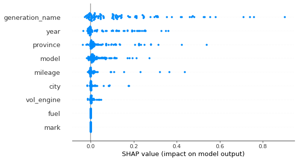

```python
shap.summary_plot(shap_values[:,0:9], X)
```